# Comparing Student’s Pooled t-test vs. Welch’s t-test

Rahul Teja Bolloju

# Student’s Pooled t-test vs. Welch’s t-test

Perform Monte Carlo simulations which estimate the power of Student’s pooled t-test and Welch’s t-test, making explicit comparisons between these two procedures. Note that both of these tests are implemented in R with the t.test() function (using the argument var.equal=TRUE for the pooled t-test).

Your simulations should sample from normal populations, varying the sample sizes n1 and n2, as well as the population standard deviations σ1 and σ2. Your goal should be to see when Student’s pooled t-test has a greater power than Welch’s t-test, or vice versa.

Create several plots of the power curves of these two tests (with the power of both Student’s pooled t-test and Welch’s t-test on the same set of axes, to make for easier comparison). Throughly investigate and discuss any evident patterns.

# Introduction

Aims to compare the power of Student’s pooled t-test and Welch’s t-test through Monte Carlo simulations. Both tests are implemented in R using the `t.test()` function, with the argument `var.equal=TRUE` for the pooled t-test.

### Student’s Pooled t-test:

- This test assumes that the variances of the two groups being compared are equal.
- It combines the variances of the two groups into a single pooled estimate, assuming they are representative of the overall population variance.
- It then calculates the t-statistic based on this pooled variance.
- Pooled t-tests are used when you are reasonably confident that the variances of the two groups being compared are approximately equal.

### Welch’s t-test:

- Welch’s t-test does not assume equal variances between the two groups.
- It’s a more robust alternative when the assumption of equal variances is violated or when you’re unsure about the equality of variances.
- It calculates the t-statistic by adjusting for the unequal variances of the two groups.
- Welch’s t-test provides a more accurate result when the sample sizes and variances between the groups are different.

## Objective

The goal is to investigate scenarios where one test exhibits greater power than the other. The simulations involve sampling from normal populations while varying sample sizes (`n1` and `n2`) and population standard deviations (`σ1` and `σ2`).

## Simulations

```r
# Function for pooled t-test
pooled_t_test <- function(sample1, sample2) {
  test <- t.test(sample1, sample2, var.equal = TRUE)
  return(test)
}

# Function for Welch's t-test
welch_t_test <- function(sample1, sample2) {
  test <- t.test(sample1, sample2, var.equal = FALSE)
  return(test)
}
```

These functions above take two samples and perform a Student’s pooled t-test and Welch’s t-test based on the `var.equal` argument. By specifying independently `var.equal` to conduct specific tests.

`var.equal=TRUE` for the Student’s pooled t-test `var.equal=FALSE` for the Welch’s t-test

```r
# Function calculates power
calculate_power <- function(n1, n2, sd1, sd2, true_difference, reps = 1000) {
  # Initialize counters for significant results
  pooled_sig <- 0
  welch_sig <- 0

  for (i in 1:reps) {
    # Generate random samples from normal distributions
    sample1 <- rnorm(n1, mean = 0, sd = sd1)
    sample2 <- rnorm(n2, mean = true_difference, sd = sd2)

    # Perform t-tests using separate functions
    pooled_test <- pooled_t_test(sample1, sample2)
    welch_test <- welch_t_test(sample1, sample2)

    # Check for significance
    if (pooled_test$p.value < 0.05) {
      pooled_sig <- pooled_sig + 1
    }
    if (welch_test$p.value < 0.05) {
      welch_sig <- welch_sig + 1
    }
  }

  # Calculate power
  pooled_power <- pooled_sig / reps
  welch_power <- welch_sig / reps

  return(list(pooled_power = pooled_power, welch_power = welch_power))
}
```

```r
# Parameters
n1_values = c(15, 25, 45, 50)
n2_values = c(35, 45, 25, 50)

sd1_values <- c(1, 2, 3, 4)
sd2_values <- c(3, 4, 1, 2)

mean_diff_values <- seq(0.5, 2, by = 0.2)
```

```r
# Create a data frame to store results
results <- data.frame()

# Perform simulations for different sample sizes, standard deviations, and mean differences
for (n1 in n1_values) {
  for (n2 in n2_values) {
    for (sd1 in sd1_values) {
      for (sd2 in sd2_values) {
        for (mean_diff in mean_diff_values) {
          powers <- calculate_power(n1, n2, sd1, sd2, true_difference = mean_diff)
          results <- rbind(results, data.frame(
            n1 = n1,
            n2 = n2,
            sd1 = sd1,
            sd2 = sd2,
            mean_difference = mean_diff,
            pooled_power = powers$pooled_power,
            welch_power = powers$welch_power
          ))
        }
      }
    }
  }
}

# head(results)
```

```r
save(results, file = "results.Rdata")
```

```r
load("results.Rdata")
head(results)
```

```
##   n1 n2 sd1 sd2 mean_difference pooled_power welch_power
## 1 15 35   1   3             0.5        0.040       0.150
## 2 15 35   1   3             0.7        0.068       0.212
## 3 15 35   1   3             0.9        0.133       0.342
## 4 15 35   1   3             1.1        0.206       0.463
## 5 15 35   1   3             1.3        0.323       0.610
## 6 15 35   1   3             1.5        0.443       0.739
```

```r
library(dplyr)
```

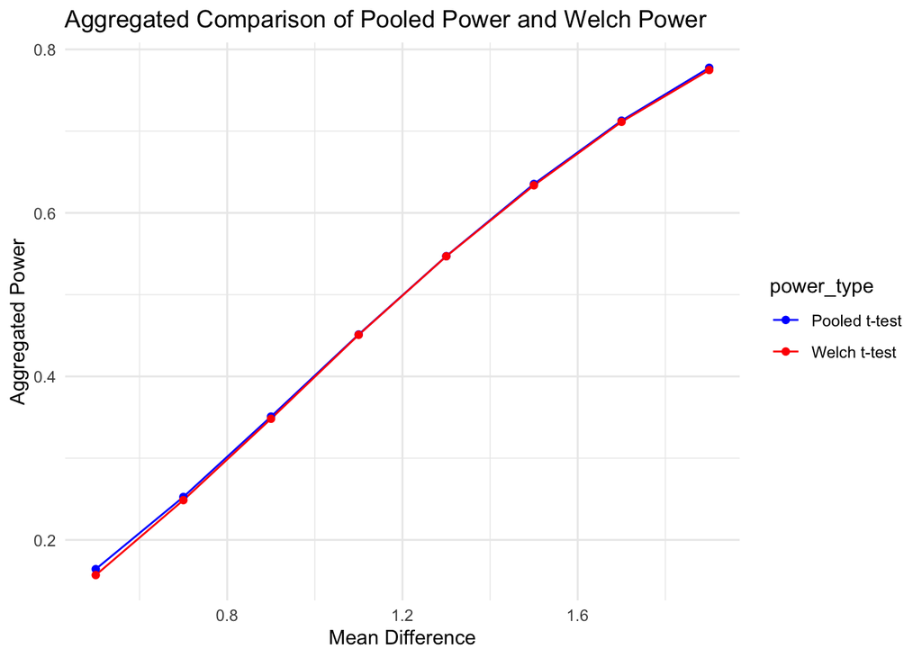

```r
library(ggplot2)

df <- results

# Gather the power values for plotting
plot_data <- tidyr::gather(df, key = "power_type", value = "power", pooled_power, welch_power)

# Aggregate the power values for the same mean_difference
aggregated_data <- plot_data %>%
  group_by(mean_difference, power_type) %>%
  summarise(avg_power = mean(power), .groups = "drop")

# head(aggregated_data)

# Create a plot showcasing aggregated power values
ggplot(aggregated_data, aes(x = mean_difference, y = avg_power, color = power_type)) +
  geom_line() +
  geom_point() +
  scale_color_manual(values = c("blue", "red"), labels = c("Pooled t-test", "Welch t-test")) +
  labs(x = "Mean Difference", y = "Aggregated Power", title = "Aggregated Comparison of Pooled Power and Welch Power") +
  theme_minimal()
```

We can observe in the plot above the comparison between the aggregated power and mean difference for both the pooled t-test and Welch’s t-test. The plot showcases the relationship between these statistical methods and how they perform concerning both power and mean difference, offering a visual representation of their effectiveness in different scenarios.

So, we’ll investigate various sample sizes and closely observe the changes in statistical power.

```
## $`15`
```

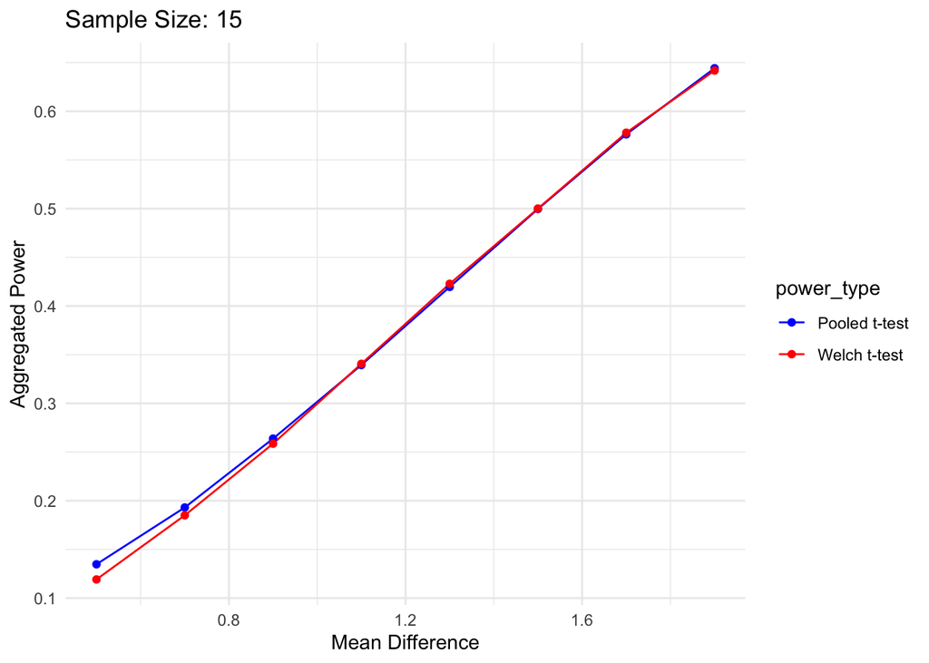

```
##
## $`25`
```

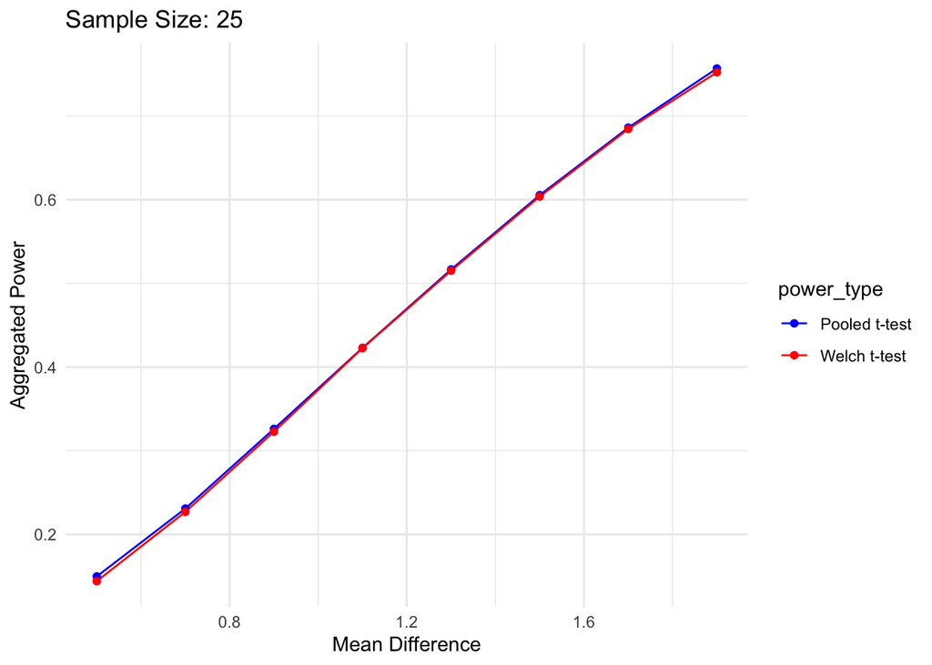

```
##
## $`45`
```

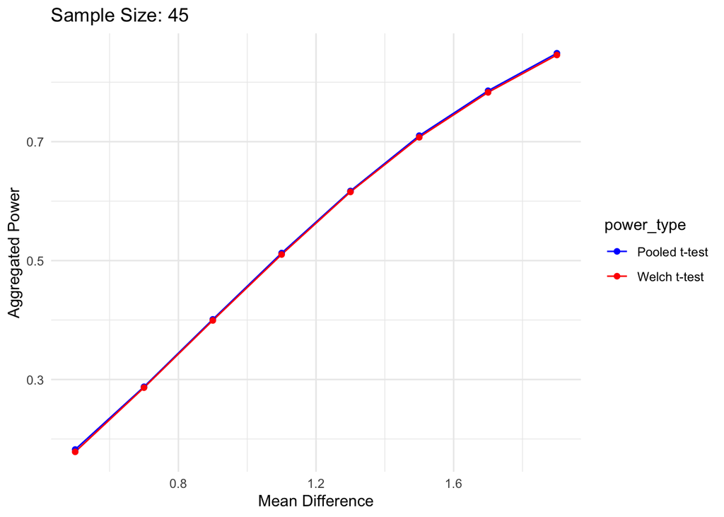

```
##
## $`50`
```

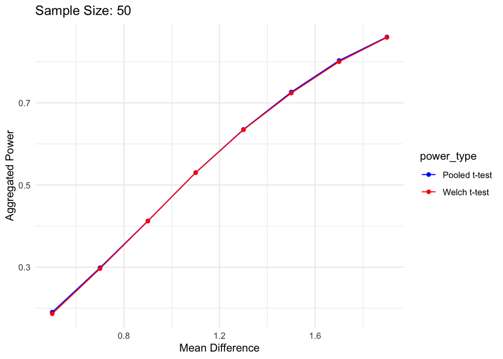

```r
library(ggplot2)
library(dplyr)
library(tidyr)

df <- results
plots_list <- list()

for (size in n1_values) {
  # Subset data for the current sample size
  subset_data <- df %>% filter(n1 == size)

  # Gather the power values for plotting
  plot_data <- tidyr::gather(subset_data, key = "power_type", value = "power", pooled_power, welch_power)

  # Aggregate the power values for the same mean_difference
  aggregated_data <- plot_data %>%
    group_by(mean_difference, power_type) %>%
    summarise(avg_power = mean(power), .groups = "drop")

  # Create a plot for the current sample size
  plot <- ggplot(aggregated_data, aes(x = mean_difference, y = avg_power, color = power_type)) +
    geom_line() +
    geom_point() +
    scale_color_manual(values = c("blue", "red"), labels = c("Pooled t-test", "Welch t-test")) +
    labs(x = "Mean Difference", y = "Aggregated Power", title = paste("Sample Size:", size)) +
    theme_minimal()

  plots_list[[as.character(size)]] <- plot
}

# View the plots
plots_list
```

```
## $`1`
```

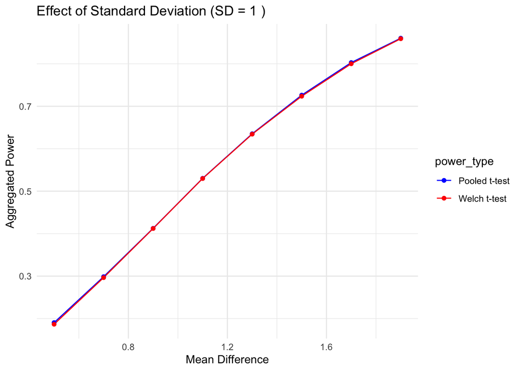

```
##
## $`2`
```

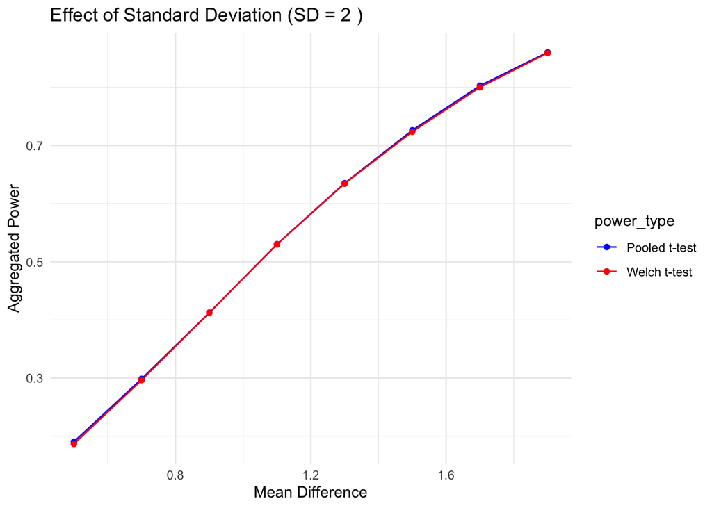

```
##
## $`3`
```

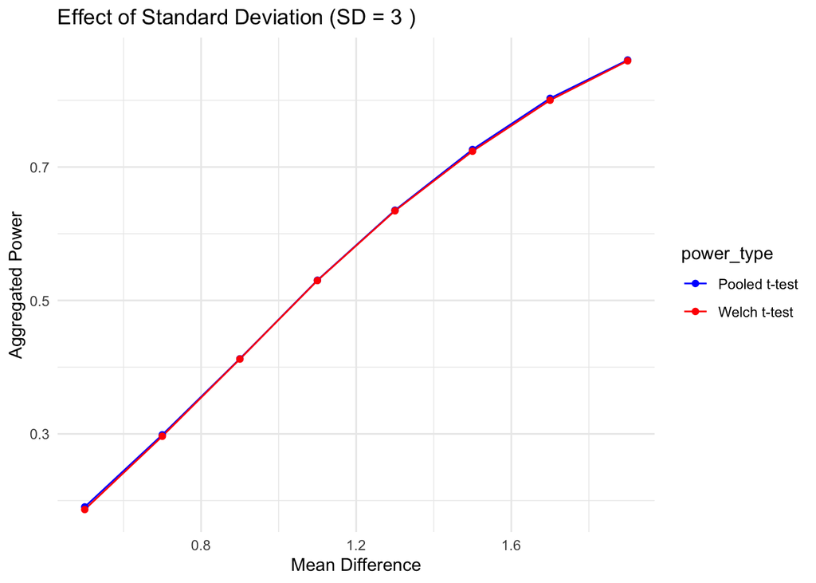

```
##
## $`4`
```

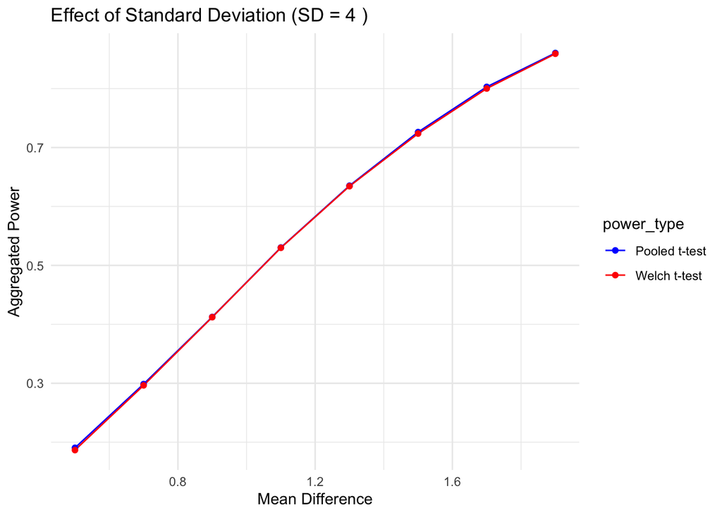

```r
# Load necessary library
library(ggplot2)
library(dplyr)

df <- results
plot_list <- list()

# Iterate through each standard deviation value
for (sd_value in sd1_values) {

  # Create a plot for each standard deviation scenario
  plot <- ggplot(aggregated_data, aes(x = mean_difference, y = avg_power, color = power_type)) +
    geom_line() +
    geom_point() +
    scale_color_manual(values = c("blue", "red"), labels = c("Pooled t-test", "Welch t-test")) +
    labs(x = "Mean Difference", y = "Aggregated Power",
         title = paste("Effect of Standard Deviation (SD =", sd_value, ")", sep = " ")) +
    theme_minimal()

  # Append the plot to the list
  plot_list[[as.character(sd_value)]] <- plot
}

plot_list
```

Let’s now take a closer look at the plots as we vary the samples and variances.

```r
plot_list <- list()

# Loop through each combination
for (n1_val in n1_values) {
  for (n2_val in n2_values) {
    for (sd1_val in sd1_values) {
      # Filter the data for the current combination
      filtered_data <- df %>%
        filter(n1 == n1_val & n2 == n2_val, sd1 == sd1_val)

      # Perform actions on the filtered data to create the plot
      plot_data <- tidyr::gather(filtered_data, key = "power_type", value = "power", pooled_power, welch_power)

      aggregated_data <- plot_data %>%
        group_by(mean_difference, power_type) %>%
        summarise(avg_power = mean(power), .groups = "drop")

      # Store the plot in the list
      plot <- ggplot(aggregated_data, aes(x = mean_difference, y = avg_power, color = power_type)) +
        geom_line() +
        geom_point() +
        scale_color_manual(values = c("blue", "red"), labels = c("Pooled t-test", "Welch t-test")) +
        labs(x = "Mean Difference", y = "Aggregated Power",
             title = paste("Scenario: n1 =", n1_val, "n2 =", n2_val, "sd1 =", sd1_val)) +
        theme_minimal()

      plot_list[[paste("n1", n1_val, "n2", n2_val, "sd1", sd1_val)]] <- plot
    }
  }
}

# plot_list
```

In total, we generated 64 plots, but I’m sharing only a select few that are clearer and easier to observe.

```
## $`n1 15 n2 35 sd1 2`
```

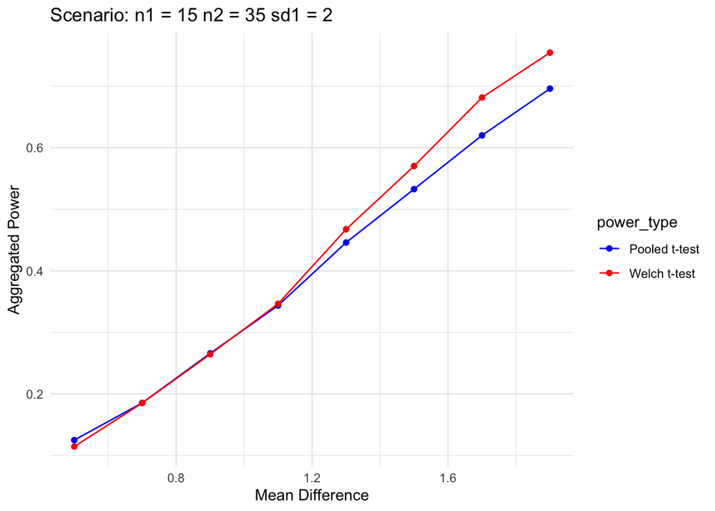

```r
plot_list[2]
```

```
## $`n1 15 n2 45 sd1 2`
```

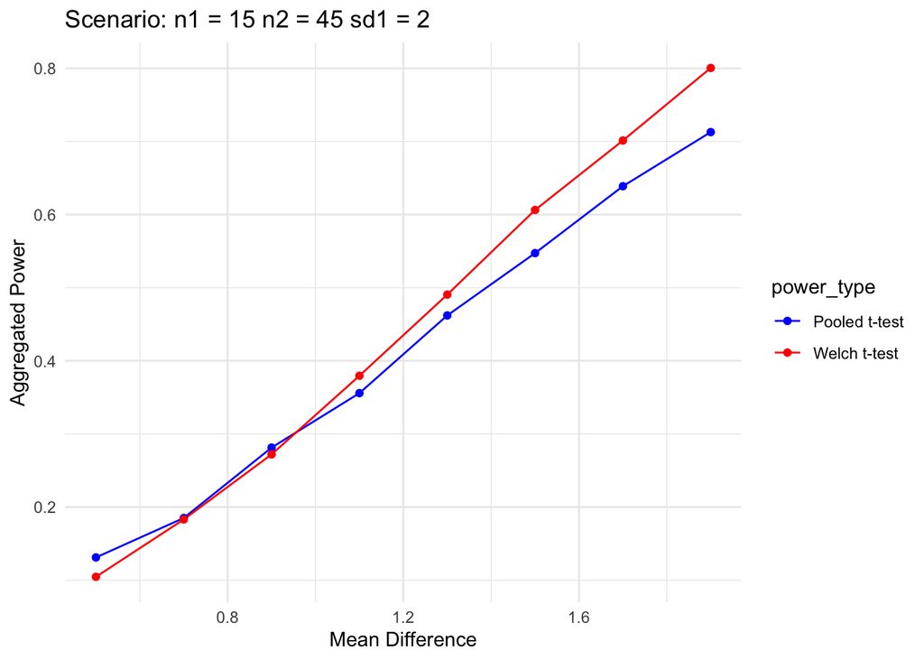

```r
plot_list[6]
```

```
## $`n1 45 n2 45 sd1 3`
```

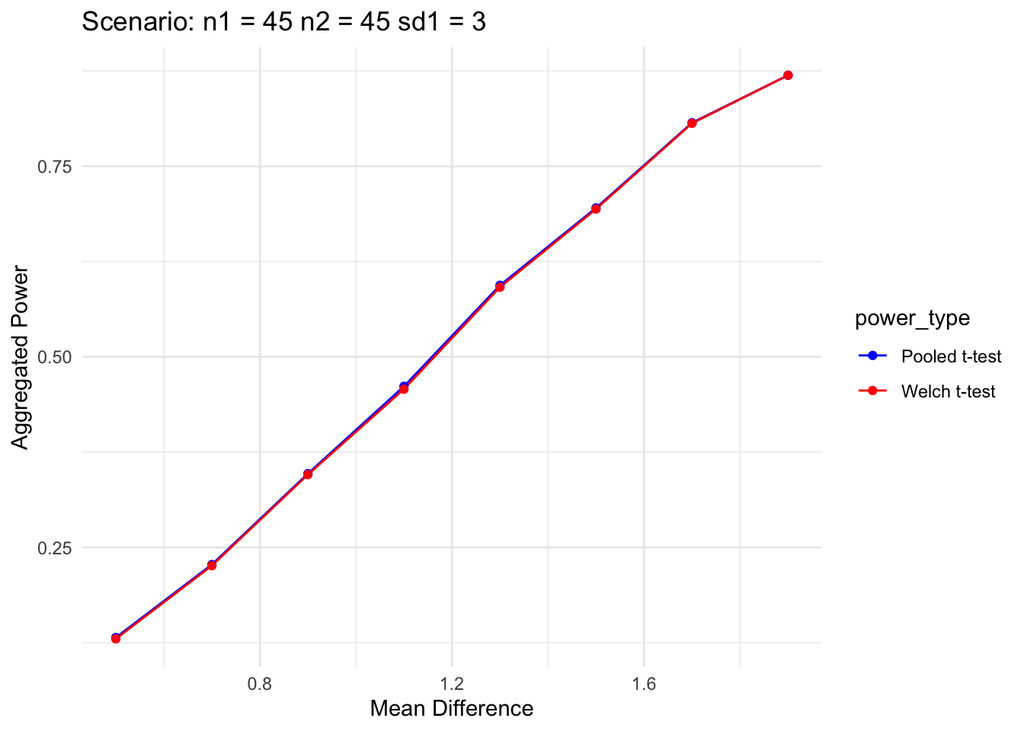

```r
plot_list[39]
```

```
## $`n1 50 n2 35 sd1 4`
```

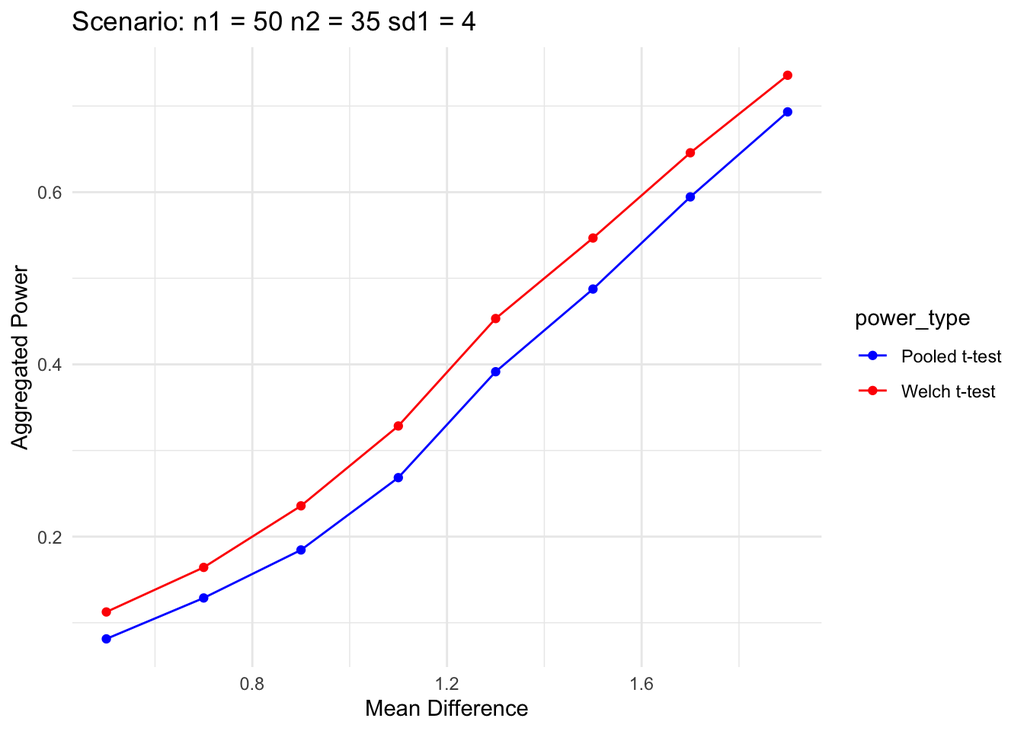

```r
plot_list[52]
```

```
## $`n1 50 n2 25 sd1 4`
```

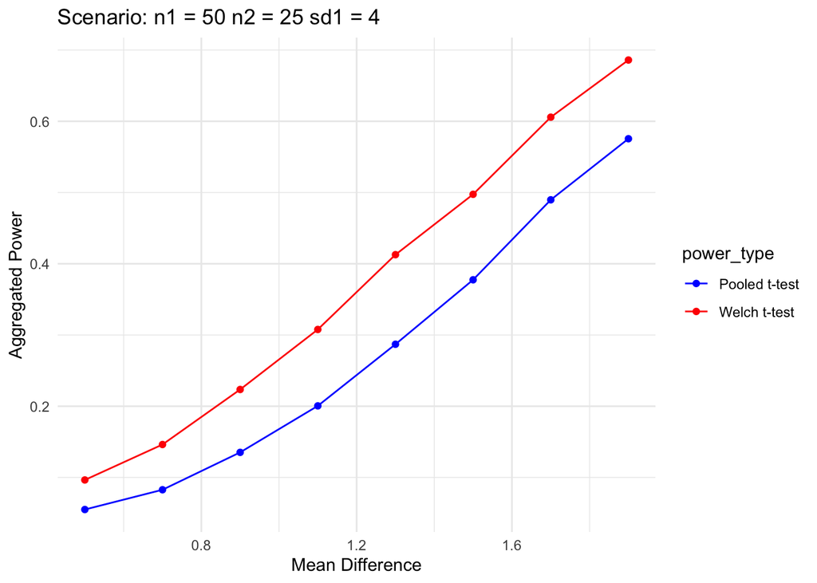

```r
plot_list[60]
```

- Impact of Sample Size: As sample sizes increase, the power of Welch’s t-test tends to become more consistent compared to the pooled t-test.
- Effect of Standard Deviation: Higher discrepancies in standard deviations tend to favor Welch’s t-test, showcasing higher power in such scenarios.

# Conclusion

The choice between Student’s pooled t-test and Welch’s t-test should consider factors such as sample sizes and standard deviations. Welch’s test does a better job overall when there is slightly more variance.